# Montoya_Lab_Statistics

Anh H. Pham

2024-02-09

Clean up the environment and load necessary libraries.

```r
# Clean up environment
rm(list=ls())

# Libraries
require(readxl)
require(rstatix)
require(ggplot2)
require(dplyr)
```

Load the xlsx data

```r
df <- read_xlsx(file.choose()) %>% as.data.frame() # Navigate to data file
head(df, 10) # Print first 10 rows of table
```

|  | StnEvent | Cruise | Date | Year | Month | Lat | Lon | MLD | ChlMD | SST | SSS | NAI | Habitat |
| --- | --- | --- | --- | --- | --- | --- | --- | --- | --- | --- | --- | --- | --- |
| 1 | EN614_03.03 | EN614 | 2018-05-09 | 2018 | May | 8.35306 | -54.41348 | 28 | 29 | 27.6615 | 32.7547 | -126.7927717 | OPM |
| 2 | EN614_03.06 | EN614 | 2018-05-09 | 2018 | May | 8.48534 | -54.50208 | 32 | 32 | 27.6375 | 33.1436 | -119.8747409 | OPM |
| 3 | EN614_03.07 | EN614 | 2018-05-09 | 2018 | May | 8.57589 | -54.51828 | 30 | 46 | 27.7035 | 33.5722 | -119.8747409 | OPM |
| 4 | EN614_03.13 | EN614 | 2018-05-10 | 2018 | May | 8.61006 | -55.08934 | 29 | 28 | 27.5017 | 33.0492 | -112.9567101 | OPM |
| 5 | EN614_06.01 | EN614 | 2018-05-11 | 2018 | May | 7.33056 | -55.59744 | 25 | 8 | 26.9118 | 31.8372 | -62.4740476 | OPM |
| 6 | EN614_06.02 | EN614 | 2018-05-11 | 2018 | May | 7.32814 | -55.59192 | 21 | 5 | 27.0488 | 32.3023 | -62.4740476 | OPM |
| 7 | EN614_08.01 | EN614 | 2018-05-12 | 2018 | May | 7.33794 | -53.76958 | 14 | 20 | 27.2579 | 30.1385 | -5.6992570 | YPC |
| 8 | EN614_08.02 | EN614 | 2018-05-12 | 2018 | May | 7.36501 | -53.81807 | 13 | 17 | 27.1891 | 30.2031 | -5.6992570 | YPC |
| 9 | EN614_10.01 | EN614 | 2018-05-13 | 2018 | May | 7.34689 | -50.89274 | 95 | 86 | 27.8379 | 35.8692 | 0.8454953 | OSW |
| 10 | EN614_10.02 | EN614 | 2018-05-13 | 2018 | May | 7.36170 | -50.88990 | 82 | 80 | 27.8707 | 35.8771 | -130.0144279 | OSW |

Define the variable and group being tested

```r
group <- 'Cruise' # Change this
variable <- 'SST' # Change this
formula <- as.formula(paste(variable,'~',group)) # Create formula for stats tests
dec <- 2 # Rounding result to dec number of decimal points
```

Checking for statistical tests assumption If no assumption is violated, do parametric test (Student’s T-test, ANOVA) If assumptions are violated, consider non-parametric test (Welch’s T-Test, Welch’s ANOVA, Kruskal-Wallis test)

```r
# Shapiro's test for normal distribution
# p-values < 0.05: Data of group doesn't follow normal distribution
shapiro <- df %>% group_by(!!sym(group)) %>% shapiro_test(!!sym(variable))
# Use !!sym(variable) to use the variable dyanmically
print(shapiro)
```

| Cruise | variable | statistic | p |
| --- | --- | --- | --- |
| AT21-04 | SST | 0.9688724 | 5.087998e-01 |
| EN614 | SST | 0.9305259 | 1.349598e-02 |
| EN640 | SST | 0.8067922 | 2.228208e-05 |
| KN197 | SST | 0.9417536 | 3.963375e-02 |
| M174 | SST | 0.9191255 | 1.764331e-04 |
| MV1110 | SST | 0.9561451 | 1.176007e-02 |

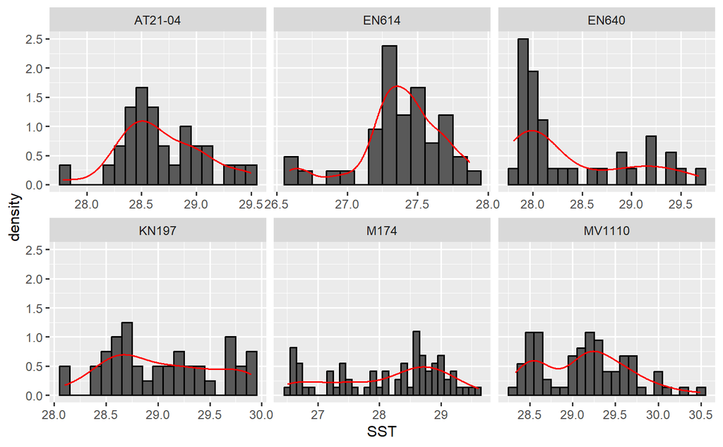

```r
# Histogram and density plot to visuallize data distribution among groups
ggplot(df, aes(x = .data[[variable]])) +
  geom_histogram(aes(y = ..density..), binwidth = 0.1, color = 'black') +
  geom_density(col = 'red') +
  facet_wrap(~ .data[[group]], scales = 'free_x')
```

```r
# Levene's test for equal variance
# p-value < 0.05: Data among group doesn't have equal variance
levene <- levene_test(df,formula)
print(levene)
```

| df1 | df2 | statistic | p |
| --- | --- | --- | --- |
| 5 | 289 | 12.11386 | 1.148711e-10 |

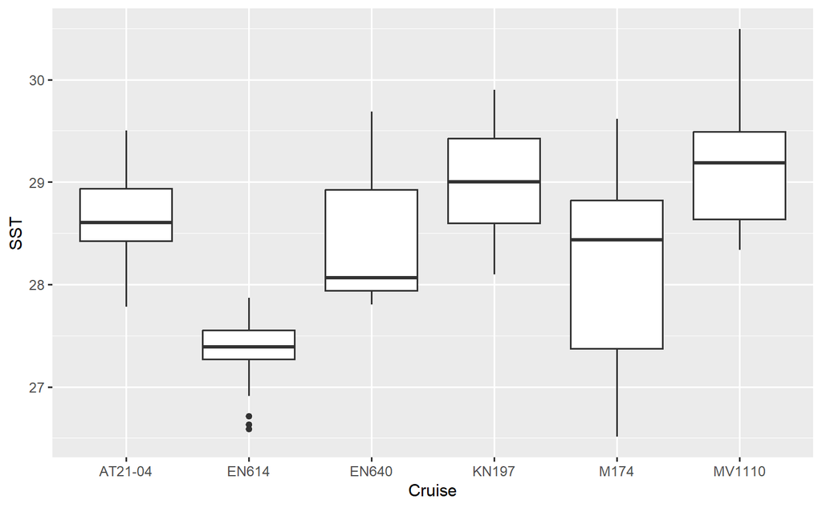

```r
# Boxplot is good for checking variances
ggplot(df, aes(x = .data[[group]], y = .data[[variable]])) +
  geom_boxplot()
```

Create table of summary statistics

```r
summary_stats <- df %>% group_by(!!sym(group)) %>%
  summarise(
    'n' = n(),
    'Mean' = round(mean(!!sym(variable), na.rm = T),dec),
    'SD' = round(sd(!!sym(variable), na.rm = T),dec),
    'Mean ± SD' = paste(Mean, '±', SD),
    'Min' = round(min(!!sym(variable), na.rm = T), dec),
    'Max' = round(max(!!sym(variable), na.rm = T), dec),
    'Median' = round(median(!!sym(variable), na.rm = T),dec),
    '25th_quantile' = round(quantile(!!sym(variable), probs = 0.25, na.rm = T), dec),
    '75th_quantile' = round(quantile(!!sym(variable), probs = 0.75, na.rm = T), dec),
    'IQR' = round(IQR(!!sym(variable), na.rm = TRUE), dec)
  ) %>% as.data.frame()
print(summary_stats)
```

| Cruise | n | Mean | SD | Mean ± SD | Min | Max | Median | 25th_quantile | 75th_quantile | IQR |
| --- | --- | --- | --- | --- | --- | --- | --- | --- | --- | --- |
| AT21-04 | 30 | 28.68 | 0.38 | 28.68 ± 0.38 | 27.78 | 29.50 | 28.60 | 28.43 | 28.93 | 0.51 |
| EN614 | 42 | 27.38 | 0.29 | 27.38 ± 0.29 | 26.59 | 27.87 | 27.39 | 27.27 | 27.55 | 0.28 |
| EN640 | 36 | 28.39 | 0.59 | 28.39 ± 0.59 | 27.80 | 29.68 | 28.07 | 27.94 | 28.92 | 0.98 |
| KN197 | 40 | 29.05 | 0.53 | 29.05 ± 0.53 | 28.10 | 29.90 | 29.00 | 28.60 | 29.42 | 0.82 |
| M174 | 73 | 28.13 | 0.90 | 28.13 ± 0.9 | 26.51 | 29.61 | 28.43 | 27.37 | 28.82 | 1.45 |
| MV1110 | 74 | 29.14 | 0.51 | 29.14 ± 0.51 | 28.34 | 30.49 | 29.18 | 28.64 | 29.49 | 0.85 |

ANOVA test to compare means of 3 or more groups Only use when no assumption was violated If p-value < 0.05: There is a significant difference in the means of the variable among the groups being tested. Tukey-HSD for pairwise comparison, only use when ANOVA p-value lower than 0.05

```r
# ANOVA
anova <- anova_test(df,formula)
print(anova)
```

```
ANOVA Table (type II tests)

  Effect DFn DFd      F        p p<.05   ges
1 Cruise   5 289 57.078 3.67e-41     * 0.497
```

```r
# Posthoc test
tukey <- tukey_hsd(df,formula)
print(tukey)
```

|  | term | group1 | group2 | null.value | estimate | conf.low | conf.high | p.adj | p.adj.signif |
| --- | --- | --- | --- | --- | --- | --- | --- | --- | --- |
| 1 | Cruise | AT21 | EN614 | 0 | -1.30117333 | -1.72011795 | -0.88222872 | 7.83e-13 | **** |
| 2 | Cruise | AT21 | EN640 | 0 | -0.29132333 | -0.72457050 | 0.14192383 | 3.86e-01 | ns |
| 3 | Cruise | AT21 | KN197 | 0 | 0.36512667 | -0.05815946 | 0.78841279 | 1.35e-01 | ns |
| 4 | Cruise | AT21 | M174 | 0 | -0.55557539 | -0.93565292 | -0.17549786 | 5.19e-04 | *** |
| 5 | Cruise | AT21 | MV1110 | 0 | 0.45839288 | 0.07906408 | 0.83772168 | 7.91e-03 | ** |
| 6 | Cruise | EN614 | EN640 | 0 | 1.00985000 | 0.61179137 | 1.40790863 | 4.88e-11 | **** |
| 7 | Cruise | EN614 | KN197 | 0 | 1.66630000 | 1.27910662 | 2.05349338 | 7.25e-13 | **** |
| 8 | Cruise | EN614 | M174 | 0 | 0.74559795 | 0.40617712 | 1.08501877 | 1.64e-08 | **** |
| 9 | Cruise | EN614 | MV1110 | 0 | 1.75956622 | 1.42098401 | 2.09814842 | 7.25e-13 | **** |
| 10 | Cruise | EN640 | KN197 | 0 | 0.65645000 | 0.25382458 | 1.05907542 | 6.51e-05 | **** |

[output cut: 5 more lines]

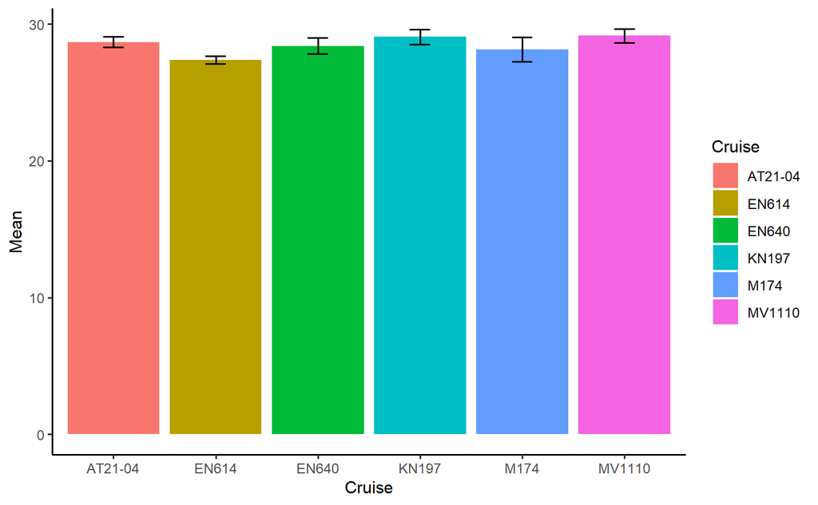

```r
# Bar plot, note that this is base on the summary_stats table
ggplot(summary_stats,aes(x = .data[[group]], y = Mean, fill = .data[[group]]))+
  geom_bar(stat = 'identity')+
  geom_errorbar(aes(ymin=Mean-SD,ymax=Mean+SD),width=0.2)+
  theme_classic()
```

Kruskal-Wallis to compare distrution of 3 or more group Use when an assumption is violated. If p-value < 0.05: There is a significant difference in the distribution of the variable among the groups being tested. Dunn’s test for pairwise comparison, Only use when KW p-value lower than 0.05

```r
# Kruskal-Wallis
kruskal <- kruskal_test(df,formula)
print(kruskal)
```

|  | .y. | n | statistic | df | p | method |
| --- | --- | --- | --- | --- | --- | --- |
| 1 | SST | 295 | 140.8927 | 5 | 1.16e-28 | Kruskal-Wallis |

```r
# Posthoc test
dunn <- dunn_test(df,formula)
print(dunn)
```

|  | .y. | group1 | group2 | n1 | n2 | statistic | p | p.adj | p.adj.signif |
| --- | --- | --- | --- | --- | --- | --- | --- | --- | --- |
| 1 | SST | AT21-04 | EN614 | 30 | 42 | -5.8501892 | 4.910141e-09 | 5.892169e-08 | **** |
| 2 | SST | AT21-04 | EN640 | 30 | 36 | -1.3559948 | 1.751008e-01 | 5.253025e-01 | ns |
| 3 | SST | AT21-04 | KN197 | 30 | 40 | 2.1934938 | 2.827182e-02 | 1.130873e-01 | ns |
| 4 | SST | AT21-04 | M174 | 30 | 73 | -2.3468109 | 1.893486e-02 | 9.467430e-02 | ns |
| 5 | SST | AT21-04 | MV1110 | 30 | 74 | 2.9377380 | 3.306163e-03 | 1.983698e-02 | * |
| 6 | SST | EN614 | EN640 | 42 | 36 | 4.6812812 | 2.850876e-06 | 2.565788e-05 | **** |
| 7 | SST | EN614 | KN197 | 42 | 40 | 8.7278888 | 2.594705e-18 | 3.632587e-17 | **** |
| 8 | SST | EN614 | M174 | 42 | 73 | 4.5929274 | 4.370712e-06 | 3.496570e-05 | **** |
| 9 | SST | EN614 | MV1110 | 42 | 74 | 10.5300098 | 6.282794e-26 | 9.424191e-25 | **** |
| 10 | SST | EN640 | KN197 | 36 | 40 | 3.7651781 | 1.664304e-04 | 1.165013e-03 | ** |

[output cut: 5 more lines]

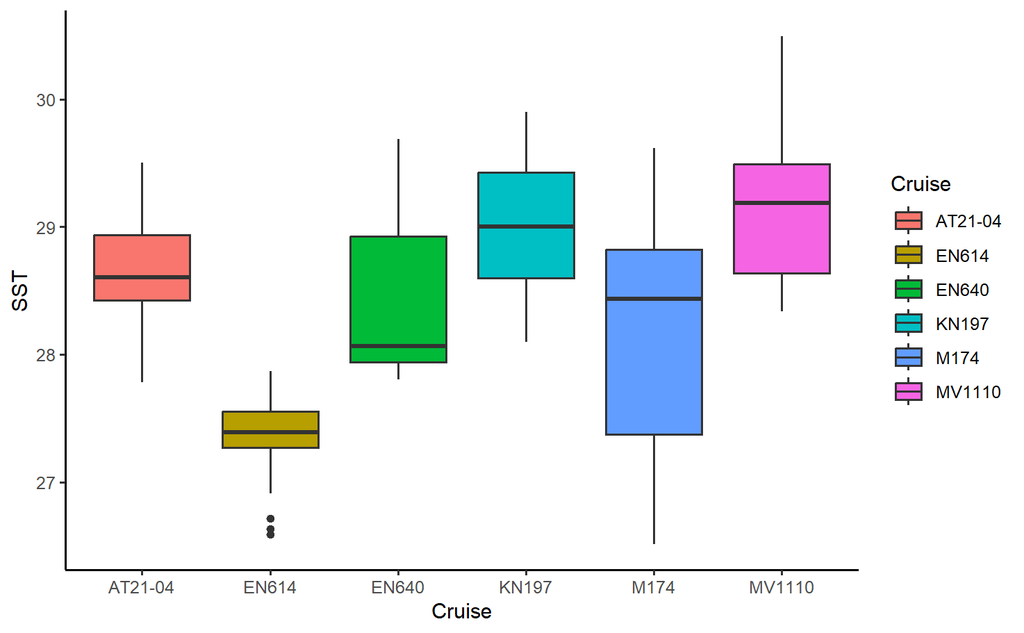

```r
# Boxplot, note that this is based on the df table
ggplot(df,aes(x = .data[[group]], y = .data[[variable]], fill = .data[[group]]))+
  geom_boxplot()+
  theme_classic()
```

T-test example Options: * equal variance (Student’s T-test) or not (Welch’s T-Test) * one-sided or two-sided * paired or unpaired

```r
# Filter for only 2 group
ds <- df %>% filter(!!sym(group) %in% c('KN197','EN614')) # Change what's in c()
ttest <- t_test(ds, formula, var.equal=T, alternative="two.sided", paired=FALSE) # Change options
print(ttest)
```

|  | .y. | group1 | group2 | n1 | n2 | statistic | df | p |
| --- | --- | --- | --- | --- | --- | --- | --- | --- |
| 1 | SST | EN614 | KN197 | 42 | 40 | -17.82852 | 80 | 1.35e-29 |

Linear Regression

```r
x = 'MLD'
y = 'ChlMD'
formula = as.formula(paste(y,'~',x))
### Linear regression
model <- lm(formula,df)
summary(model)
```

```
Call:
lm(formula = formula, data = df)

Residuals:
    Min      1Q  Median      3Q     Max
-52.764 -26.573  -6.607  15.475  97.383

Coefficients:
            Estimate Std. Error t value Pr(>|t|)
(Intercept)  29.5357     2.3183  12.740   <2e-16 ***
MLD           0.5045     0.0545   9.256   <2e-16 ***
---
Signif. codes:  0 ‘***’ 0.001 ‘**’ 0.01 ‘*’ 0.05 ‘.’ 0.1 ‘ ’ 1

Residual standard error: 31.32 on 293 degrees of freedom
Multiple R-squared:  0.2262,    Adjusted R-squared:  0.2236
F-statistic: 85.67 on 1 and 293 DF,  p-value: < 2.2e-16
```

```r
# Extract and print the model equation
coefficients <- coef(model) %>% round(2)
cat("Model function: y =", coefficients[2], "*x + ", coefficients[1], "\n")
```

```
Model function: y = 0.5 *x +  29.54
```

```r
# Extract and print R-squared value
r_squared <- summary(model)$r.squared %>% round(2)
cat("R-squared value:", r_squared, "\n")
```

```
R-squared value: 0.23
```

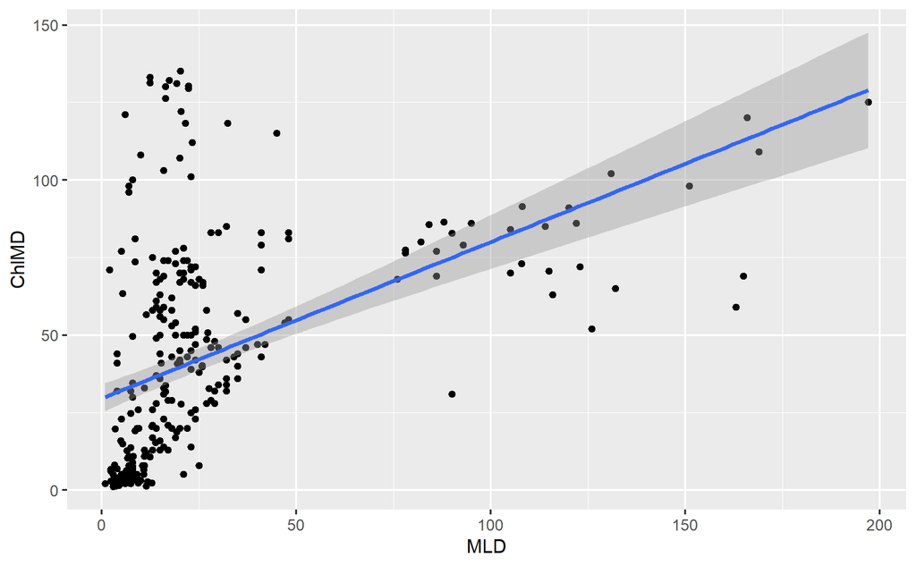

```r
# Scatter plot
ggplot(df,aes(x=.data[[x]],y=.data[[y]]))+
  geom_point()+
  geom_smooth(method='lm',formula=y~x)
```

[output not shown]